# Homework Assignment #1

Robert Hereth

9/1/2021

# Problem 1

## Problem Statement

Recreate the `ggplot` as seen in the Unit 1 Notes 1 document, Problem 1.

## Solution

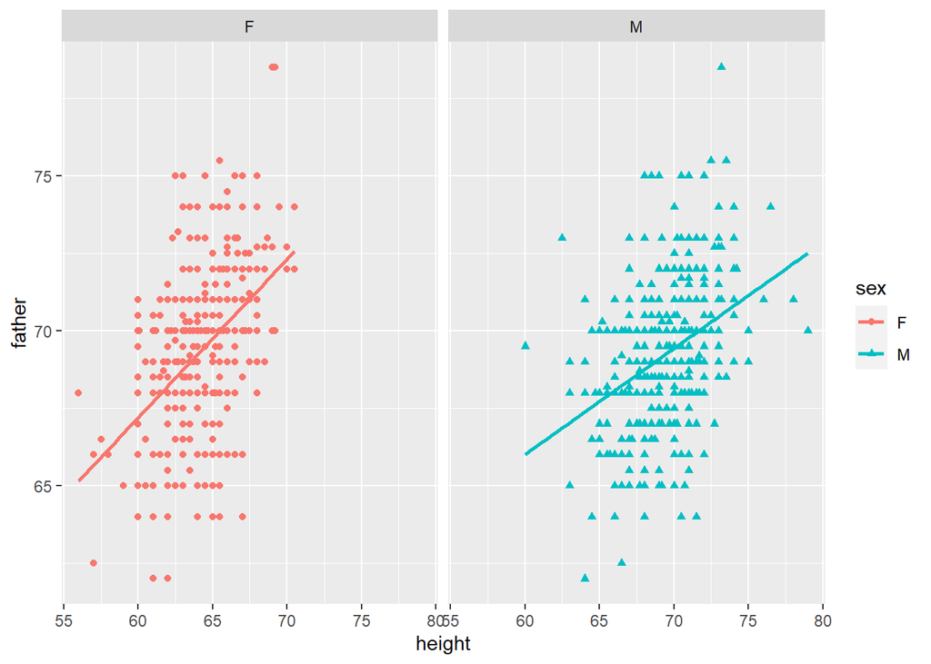

```r
library(tidyverse)
library(mosaic)
galton <- Galton
ggplot(galton, aes(height, father, color=sex, shape=sex)) +
  geom_point() +
  geom_smooth(method=lm, se=F) +
  facet_wrap(vars(sex))
```

# Problem 2

## Problem Statement

Using the `Marriage` data set from the `mosaic` package, recreate the given plot and create a unique, informative plot.

## Part A

The plot below depicts the influence of `age` and `race` on the officiator of the given marriage. From this plot, we can see that the majority of White marriages have a minister, pastor, or marriage official lead the wedding, whereas most Hispanic marriages are lead by a marriage official.

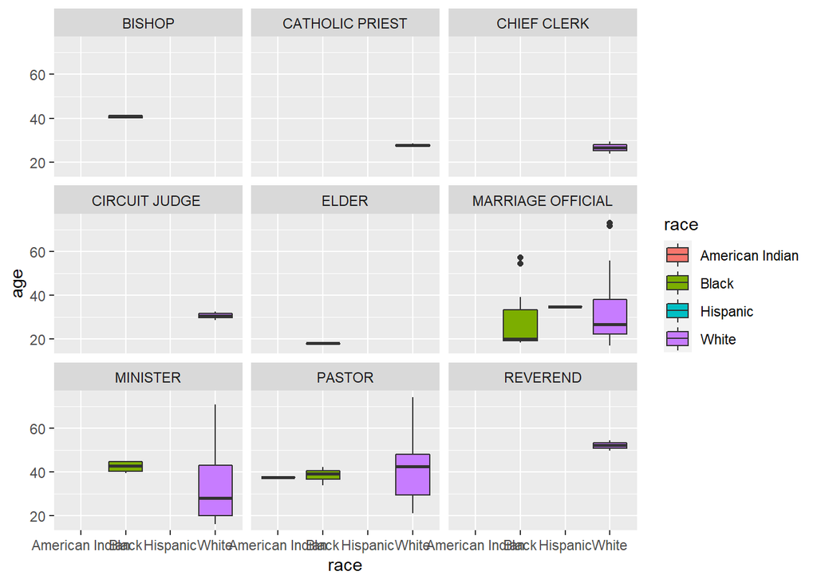

```r
library(tidyverse)
library(mosaic)
marriage <- Marriage
ggplot(marriage, aes(race, age, fill=race)) +
  geom_boxplot() +
  facet_wrap(vars(officialTitle))
```

## Part B

The plot generated below depicts the influence of astrological signs, age, and sex on the number of marriages. This plot leads us to believe that brides marry earlier, and grooms marry later. We also see that Libra, Pisces, and Sagittarius grooms are more married than any other sign, and brides remain mostly unaffected by astrological signs.

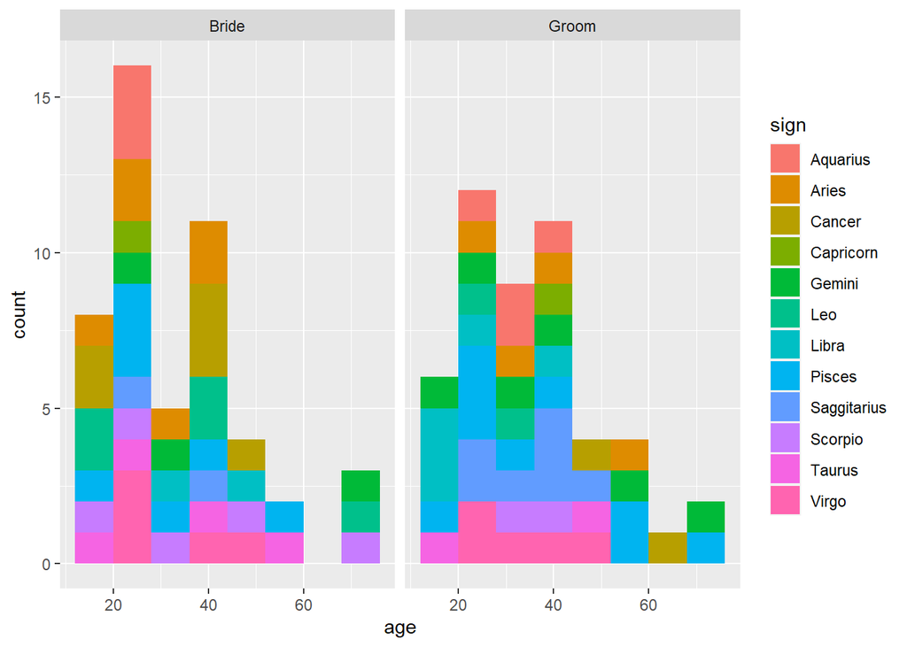

```r
library(tidyverse)
library(mosaic)
marriage <- Marriage
ggplot(marriage, aes(age, fill=sign)) +
  geom_histogram(binwidth=8) +
  facet_wrap(vars(person))
```

# Problem 3

## Problem Statement

Recreate the graphic shown using the `MLB_teams` data from the `mdsr` package, and discuss what could be changed to make the graphic better.

## Solution

This graphic can be created using the `ggplot` command `geom_text`, creating a scatter plot out of text. We then use the `ggplot` attributes `color` and `size` in order to fully match the example. As far as improvements, there needs to be a way to see what year these were from, so using the `facet_wrap` command to split the plots by year rather than leagues, as the color already separates leagues.

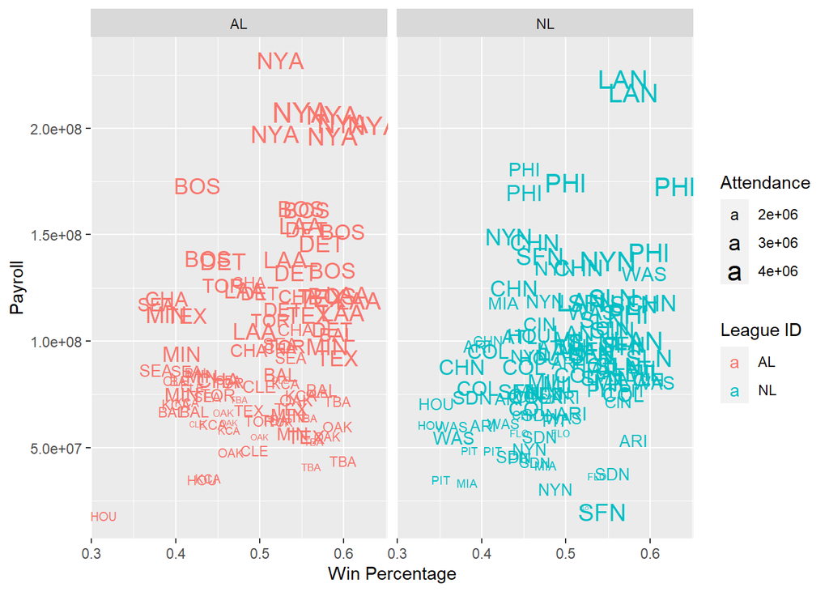

```r
library(tidyverse)
library(mdsr)
mlb <- MLB_teams
ggplot(mlb, aes(WPct, payroll, color=lgID, size=attendance)) +
  geom_text(label=mlb$teamID) +
  facet_grid(cols=vars(lgID)) +
  labs(x="Win Percentage", y="Payroll", color="League ID", size="Attendance")
```

# Problem 4

## Problem Statement

Using the `titanic` dataset, recreate the three plots shown.

## Solution

The following three plots are recreations of ones from the assignment given:

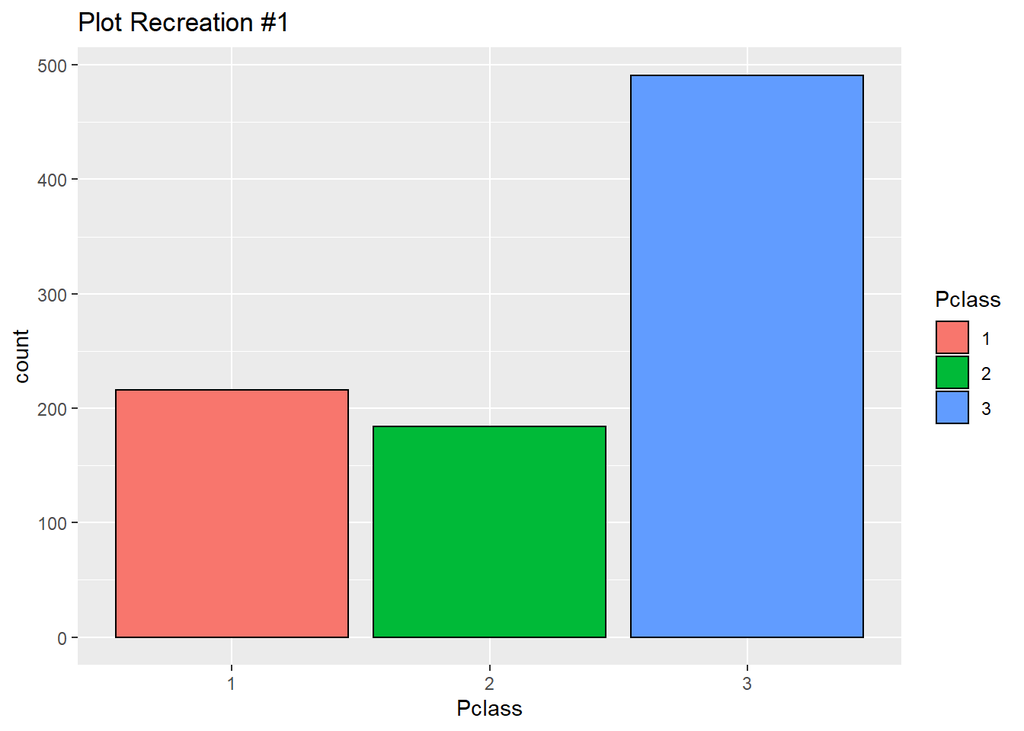

```r
library(tidyverse)
library(readr)
titanic <- read_csv("C:/Users/mechg/Downloads/titanic (1).csv")
titanic$Pclass <- as.factor(titanic$Pclass)
titanic$Sex <- as.factor(titanic$Sex)
# Plot 1
ggplot(titanic, aes(Pclass, fill=Pclass)) +
  geom_bar(color="black") +
  labs(title="Plot Recreation #1")
```

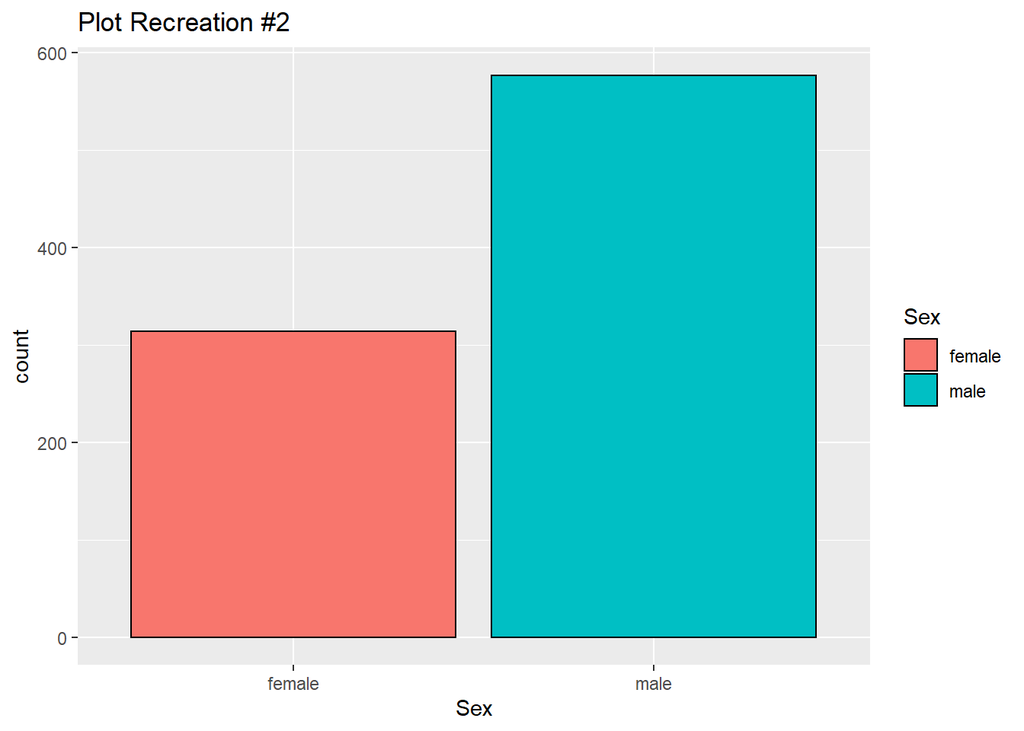

```r
# Plot 2
ggplot(titanic, aes(Sex, fill=Sex)) +
  geom_bar(color="black") +
  labs(title="Plot Recreation #2")
```

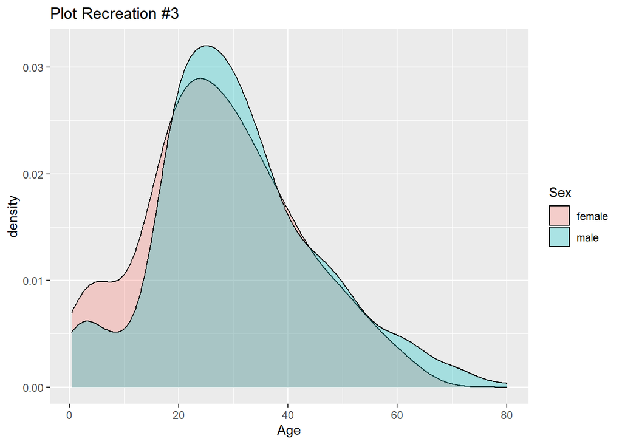

```r
# Plot 3
ggplot(titanic, aes(Age, fill=Sex)) +
  geom_density(alpha=.3) +
  labs(title="Plot Recreation #3")
```

# Problem 5

## Problem Statement

Recreate the plot shown in the book using the dataset `RailTrail`, (which I 100% looked at the help section for :-) ), and make a plot that looks abysmal using as many variables as possible.

## Solution

The first plot is a recreation of the one shown on the assignment, and the second plot is a “horrible plot” example, showing many variables that have no logical relation or proper labels.

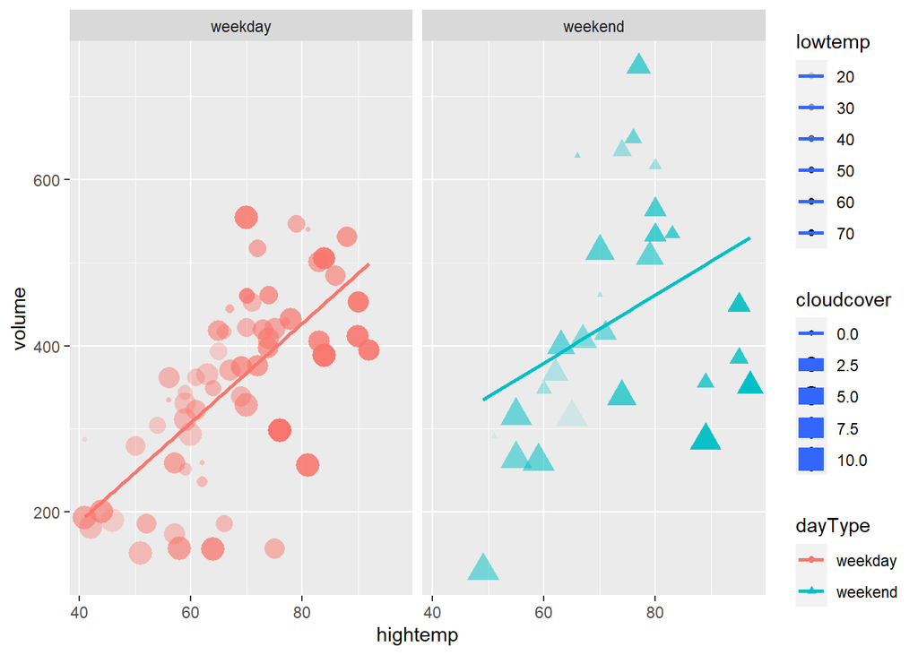

```r
library(mosaic)
library(tidyverse)
rail <- RailTrail
ggplot(rail, aes(hightemp, volume, color=dayType, alpha=lowtemp, size=cloudcover, shape=dayType)) +
  geom_point() +
  geom_smooth(method=lm, se=F) +
  facet_wrap(~dayType)
```

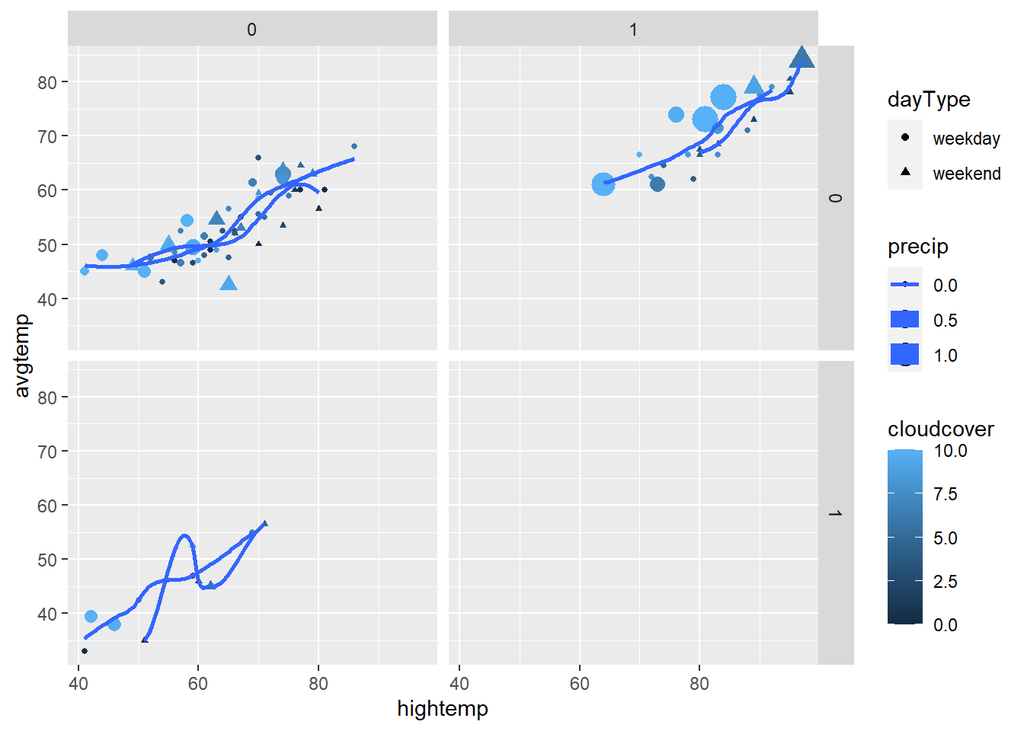

```r
ggplot(rail, aes(hightemp, avgtemp, color=cloudcover, shape=dayType, size=precip, pch=spring)) +
  geom_point() +
  geom_smooth(method=loess, se=F) +
  facet_grid(cols=vars(summer), rows=vars(fall))
```